# Appendix

1. Setting Globals
2. Entire Graph
3. Product-Product Projection
4. Filter Graph and Add Metadata
5. Evaluating Genres
   1. Top 5 Categories in each Genre
   2. Basic Genre Stats
   3. Helpfulness and Genre
   4. Rating and Genre
6. CUG and QAP Testing for Kicks
7. Betweenness

### Setting Globals

Before starting the analysis, we need to set a `seed` to ensure these results are reproducable. Also, adding some variables for color for consistency throughout the analysis.

```r
set.seed(666)
co.purple.0 <- "#9C27B0"
co.purple.1 <- "#E1BEE7"
```

### Entire Graph

Load graph with all nodes, products, users, and categories.

```r
g.1 <- read_graph('./_save/1-g-cpu.graphml', 'graphml')

summary(g.1)
```

```
## IGRAPH DN-- 9418 95144 --
## + attr: top_category (v/c), helpful_up_total (v/n), name (v/c),
## | title (v/c), price (v/n), degree_total (v/n), rating_median
## | (v/n), helpful_ratio_mean (v/n), node_type (v/c), helpful_total
## | (v/n), full_name (v/c), degree_out (v/n), top_category_rank
## | (v/n), rating_mean (v/n), degree_in (v/n), id (v/c),
## | helpful_ratio_median (v/n), helpful_2 (e/n), helpful_1 (e/n),
## | overall (e/n), edge_type (e/c), unixReviewTime (e/n)
```

```r
table(V(g.1)$node_type)
```

```
##
## category  product     user
##      309     3568     5541
```

```r
table(E(g.1)$edge_type)
```

```
##
## d_category_includes_product     d_category_is_parent_of
##                       30114                         324
##              d_has_reviewed
##                       64706
```

```r
data.frame(
  Attribute=sort(vertex_attr_names(g.1)),
  Description=c(
    "Node in degree.",
    "Node out degree.",
    "Node total degree.",
    "Full public name of user.",
    "Product or user helpfulness ratio mean over all connected reviews.",
    "Product or user helpfulness ratio median over all connected reviews.",
    "Product or user helpfulness total number of votes over all connected reviews.",
    "Product or user helpfulness up vote total over all connected reviews.",
    "Id of node for graphml format.",
    "Product ASIN, user ID, or category name.",
    "Either 'product', 'user', or 'category'.",
    "Price of product.",
    "Product or user mean rating over all connected reviews.",
    "Product or user median rating over all connected reviews.",
    "Title of product.",
    "Top category of product, in this case all values are 'Music'.",
    "All time top ranking within the Music category."
  )
)
```

```
##               Attribute
## 1             degree_in
## 2            degree_out
## 3          degree_total
## 4             full_name
## 5    helpful_ratio_mean
## 6  helpful_ratio_median
## 7         helpful_total
## 8      helpful_up_total
## 9                    id
## 10                 name
## 11            node_type
## 12                price
## 13          rating_mean
## 14        rating_median
```

[output cut: 21 more lines]

```r
data.frame(
  Attribute=sort(edge_attr_names(g.1)),
  Description=c(
    "Either 'd_category_includes_product' (category->product), 'd_category_is_parent_of' (category->category), or 'd_has_reviewed' (user->product).",
    "Review helpfulness up vote total.",
    "Review helpfulness up and down vote total.",
    "Review overall score [0,5]",
    "Unix time of review."
  )
)
```

```
##        Attribute
## 1      edge_type
## 2      helpful_1
## 3      helpful_2
## 4        overall
## 5 unixReviewTime
##                                                                                                                                      Description
## 1 Either 'd_category_includes_product' (category->product), 'd_category_is_parent_of' (category->category), or 'd_has_reviewed' (user->product).
## 2                                                                                                              Review helpfulness up vote total.
## 3                                                                                                     Review helpfulness up and down vote total.
## 4                                                                                                                     Review overall score [0,5]
## 5                                                                                                                           Unix time of review.
```

Save graph for next step.

```r
write_graph(g.1, './_save/2-g-cpu.graphml', 'graphml')
```

### Product-Product Projection

Project bipartite network into product-product network over user reviews.

```r
g.2 <- read_graph('./_save/2-g-cpu.graphml', 'graphml')
g.2 <- delete_vertices(g.2, V(g.2)[V(g.2)$node_type == 'category'])
V(g.2)$type <- V(g.2)$node_type == 'product'
table(V(g.2)$node_type)
g.2 <- bipartite_projection(g.2, which='true')
write_graph(g.2, './_save/3-g-pp.graphml', 'graphml')
```

Load and provide a summary of the product-product network.

```r
summary(read_graph('./_save/3-g-pp.graphml', 'graphml'))
```

```
## IGRAPH UNW- 3568 829575 --
## + attr: top_category (v/c), helpful_up_total (v/n), name (v/c),
## | title (v/c), price (v/n), degree_total (v/n), rating_median
## | (v/n), helpful_ratio_mean (v/n), node_type (v/c), helpful_total
## | (v/n), full_name (v/c), degree_out (v/n), top_category_rank
## | (v/n), rating_mean (v/n), degree_in (v/n), id (v/c),
## | helpful_ratio_median (v/n), weight (e/n)
```

### Filter Graph and Add Metadata

Visualize edge weights and filter out low weight edges and low strenght nodes.

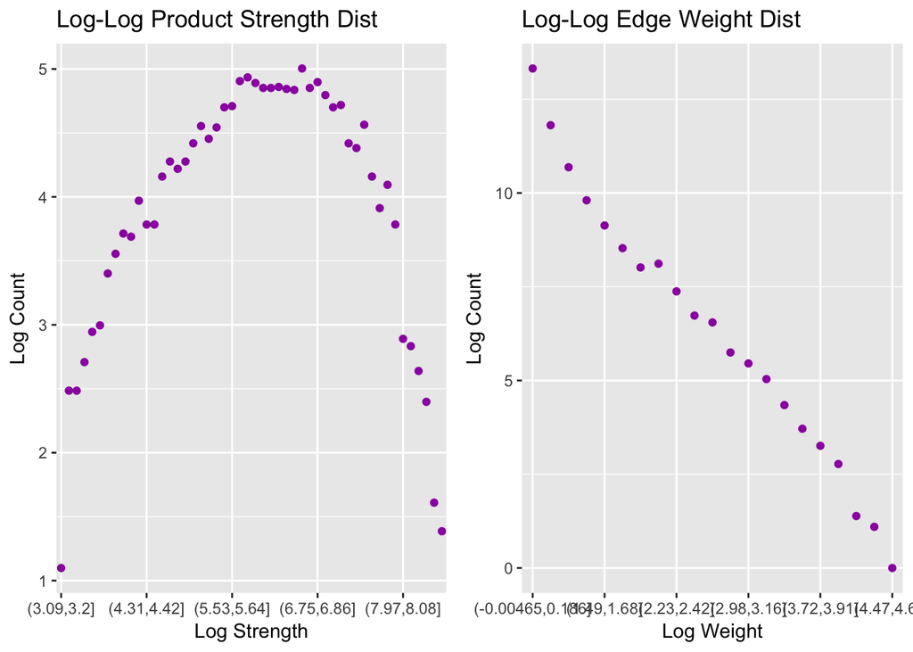

```r
g.3 <- read_graph('./_save/3-g-pp.graphml', 'graphml')

g.3.strengths <- log(strength(g.3))
strengths.breaks <- seq(from=0, to=max(g.3.strengths) + 1)
strengths.df <- data.frame(table(cut(g.3.strengths, breaks=50)))
strengths.df <- strengths.df[strengths.df$Freq > 0,]
strengths.df$log_bin <- strengths.df$Var1
strengths.df$log_freq <- log(strengths.df$Freq)
names(strengths.df) <- c('bin', 'freq', 'log_bin', 'log_freq')
f.plot.ls <- ggplot(
    strengths.df,
    aes(
      x=bin,
      y=log_freq
    )
  ) +
  geom_point(
    color=co.purple.0
  ) +
  ggtitle('Log-Log Product Strength Dist') +
  xlab('Log Strength') +
  ylab('Log Count') +
  scale_y_continuous() +
  scale_x_discrete(
    breaks=levels(strengths.df$bin)[c(T, rep(F, 10))]
  )
g.3.weights <- log(E(g.3)$weight)
weights.breaks <- seq(from=0, to=max(g.3.weights) + 1)
weights.df <- data.frame(table(cut(g.3.weights, breaks=25)))
weights.df <- weights.df[weights.df$Freq > 0,]
weights.df$log_bin <- weights.df$Var1
weights.df$log_freq <- log(weights.df$Freq)
names(weights.df) <- c('bin', 'freq', 'log_bin', 'log_freq')
f.plot.lw <- ggplot(
    weights.df,
    aes(
      x=bin,
      y=log_freq
    )
  ) +
  geom_point(
    color=co.purple.0
  ) +
  ggtitle('Log-Log Edge Weight Dist') +
  xlab('Log Weight') +
  ylab('Log Count') +
  scale_y_continuous() +
  scale_x_discrete(
    breaks=levels(weights.df$bin)[c(T, rep(F, 3))]
  )
filter.df.1 <- data.frame(edge_weight=E(g.3)$weight)
f.plot.ew <- ggplot(
  filter.df.1,
  aes(
    x=edge_weight
  )
) +
  geom_histogram(
    binwidth=1,
    fill=co.purple.0
  ) +
  ggtitle('Edge Weight Dist') +
  xlab('Weight') +
  ylab('Count')
filter.df.2 <- data.frame(strength=strength(g.3))
f.plot.s <- ggplot(
  filter.df.2,
  aes(
    x=strength
  )
) +
  geom_histogram(
    binwidth=50,
    fill=co.purple.0
  ) +
  ggtitle('Product Strength Dist') +
  xlab('Strength') +
  ylab('Count')

g.3 <- delete_edges(g.3, E(g.3)[E(g.3)$weight < 2])
g.3 <- delete_vertices(g.3, V(g.3)[strength(g.3) <= 50])

filter.df.1 <- data.frame(edge_weight=E(g.3)$weight)
f.plot.ew.a <- ggplot(
  filter.df.1,
  aes(
    x=edge_weight
  )
) +
  geom_histogram(
    binwidth=1,
    fill=co.purple.1
  ) +
  ggtitle('Edge Weight Dist, Filtered') +
  xlab('Weight') +
  ylab(NULL)
filter.df.2 <- data.frame(strength=strength(g.3))
f.plot.s.a <- ggplot(
  filter.df.2,
  aes(
    x=strength
  )
) +
  geom_histogram(
    binwidth=50,
    fill=co.purple.1
  ) +
  ggtitle('Product Strength Dist, Filtered') +
  xlab('Strength') +
  ylab(NULL)

multiplot(f.plot.ls, f.plot.lw, cols=2)
```

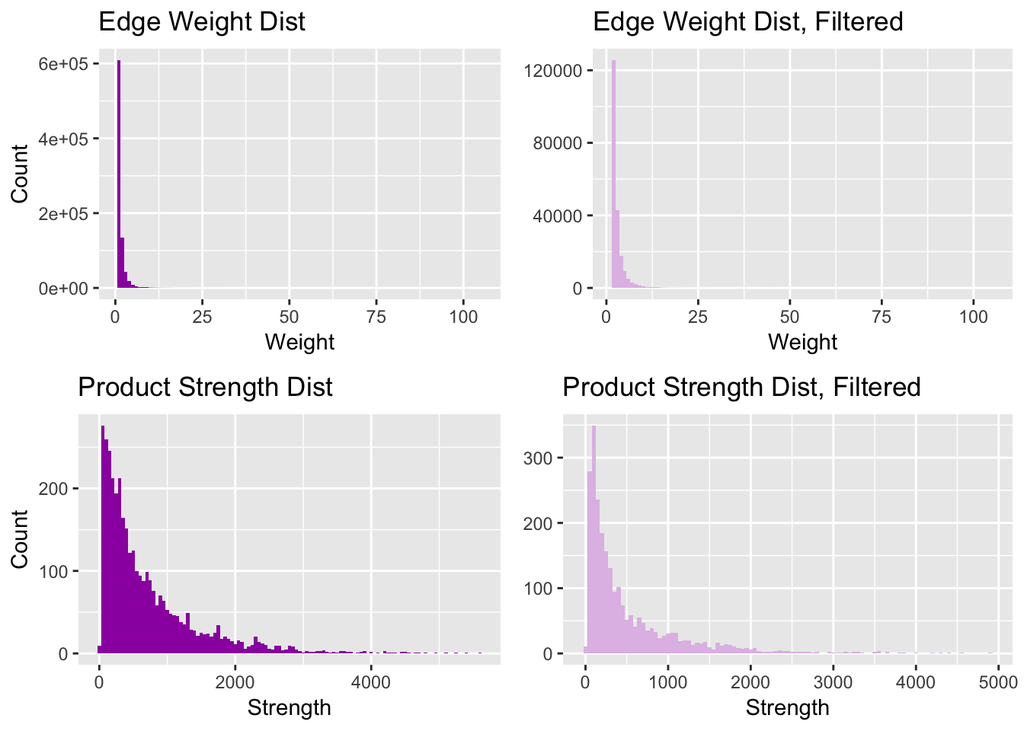

```r
multiplot(f.plot.ew, f.plot.s, f.plot.ew.a, f.plot.s.a, cols=2)
```

Now we run some clustering algorithms. Note, we’re not running betweenness because this product-product projection is enormous and we don’t have access to a computer powerful enough to calculate this in a reasonable time.

```r
le <- cluster_leading_eigen(g.3)
fg <- cluster_fast_greedy(g.3)
# bt <- cluster_edge_betweenness(g.3)
wt <- cluster_walktrap(g.3)
wt10 <- cluster_walktrap(g.3, steps=10)

saveRDS(le, './_save/le.rds')
saveRDS(fg, './_save/fg.rds')
saveRDS(wt, './_save/wt.rds')
saveRDS(wt10, './_save/wt10.rds')
```

Visualize some stats about clusters and choose the best one on quantitative and qualitative attributes. We chose leading eigenvector clusters because they have relatively high modularity and successfully isolate outliers and items in the *Digital Music* category, which we don’t want to include in this analysis.

```r
le <- readRDS('./_save/le.rds')
fg <- readRDS('./_save/fg.rds')
wt <- readRDS('./_save/wt.rds')
wt10 <- readRDS('./_save/wt10.rds')

clusterings.framed <- data.frame(
  Algorithm=c("Leading Eigenvector", "Fastgreedy", "Walktrap 4 Steps", "Walktrap 10 Steps"),
  Number_of_Clusters=c(length(le), length(fg), length(wt), length(wt10)),
  Modularity=as.numeric(lapply(list(le, fg, wt, wt10), modularity))
)
clusterings.framed[order(clusterings.framed$Modularity, decreasing=TRUE),]
```

```
##             Algorithm Number_of_Clusters Modularity
## 3    Walktrap 4 Steps                 14  0.4141556
## 1 Leading Eigenvector                  7  0.3990322
## 4   Walktrap 10 Steps                  9  0.3905654
## 2          Fastgreedy                  5  0.3814987
```

```r
V(g.3)$community_id_le <- membership(le)
V(g.3)$community_id_fg <- membership(fg)
V(g.3)$community_id_wt <- membership(wt)
V(g.3)$community_id_wt10 <- membership(wt10)
```

At this point we add category metadata to the product-product projection so that we can use them to label our genres. It was easier to do this step with python tooling than R, please refer to python code if you are interested in how this was done; specifically the `add_categories` function in `graph_tools.py`.

### Evaluating Genres

As stated before, we chose to use leading eigenvector clustering for our clusters. Communties 6 and 7 represent outliers and the *Digital Music* category, so we remove those. We also remove the *Pop* and *Rock* categories because these are significantly more connected than all the other categoires; using them in our analysis would be too generic.

```r
g.5 <- read_graph('./_save/5-g-ppc.graphml', 'graphml')

clustering <- readRDS('./_save/le.rds')

# delete some vertices we don't want (only relevant for le)
g.5 <- delete_vertices(g.5, V(g.5)$community_id_le == "6")
g.5 <- delete_vertices(g.5, V(g.5)$community_id_le == "7")

community_ids <- names(table(V(g.5)$community_id_le))

# remove categories that connect too much
head(sort(igraph.degree(g.5, V(g.5)$node_type=='category'), decreasing=TRUE), 5)
```

```
##                Pop               Rock               Soul
##               1486                869                536
##            Pop Rap Singer-Songwriters
##                507                426
```

```r
g.5 <- delete_vertices(g.5, V(g.5)$name == "Pop")
g.5 <- delete_vertices(g.5, V(g.5)$name == "Rock")
head(sort(igraph.degree(g.5, V(g.5)$node_type=='category'), decreasing=TRUE), 5)
```

```
##               Soul            Pop Rap Singer-Songwriters
##                536                507                424
## Gangsta & Hardcore      Indie & Lo-Fi
##                418                307
```

#### Top 5 Categories in each Genre

To get an idea of what “genre” a community represents we summarized the top 5 most connected category nodes in each community. Note: a product could be counted more than once in these frequencies, so the total of these counts is not the number of products in the genre.

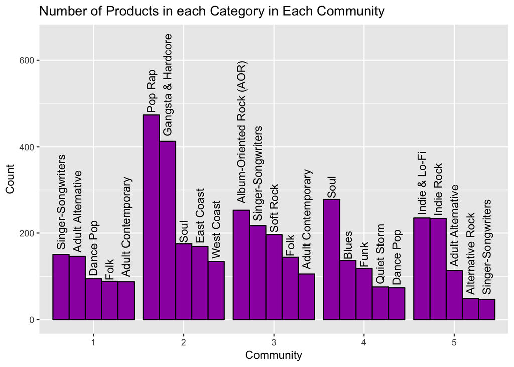

```r
top_categories <- data.frame()
pre_edges <- E(g.5)[E(g.5)$edge_type == 'd_category_includes_product']
for (cid in community_ids) {
  unique_categories <- c()
  for (pid in communities(clustering)[cid]) {
    unique_categories <- c(unique_categories, tail_of(g.5, pre_edges[to(V(g.5)[pid])])$name)
  }
  tops <- head(sort(table(unique_categories), decreasing=TRUE), n=5)

  if (length(tops) > 1) {
    c.frame <- data.frame(
      tops,
      Community=cid
    )
  } else if (length(tops) == 1) {
    c.frame <- data.frame(
      unique_categories=unique(unique_categories),
      Freq=table(unique_categories)[[1]],
      Community=cid
    )
  }
  top_categories <- rbind(top_categories, c.frame)
}
names(top_categories) <- c("Category", "Count", "Community")
top_categories$Id <- rep(c(1:5),5)
f.topCats <- ggplot(
  top_categories,
  aes(
    x=Community,
    y=Count,
    group=Id,
    label=Category
  )
) +
  geom_bar(
    stat="identity",
    color="black",
    fill=co.purple.0,
    position="dodge"
  ) +
  geom_text(
    angle=90,
    position=position_dodge(width=0.9),
    hjust=-0.05
  ) +
  ylim(0, 650) +
  ggtitle("Number of Products in each Category in Each Community") +
  guides(fill=FALSE)
f.topCats
```

#### Basic Genre Stats

For the next steps, we first remove `category` nodes because we don’t to include these for calucations going forward. Then, we visualize some basic stats about each community. Interesting to note that genre 2 and 3 have about the same number of products and reviews, but genre 2 has much higher strength nodes than all the other communties. Might be related to what we’ll see later genre 2 having a very wide rating range. Genre 2 must have a tight community while 3 has a much looser community of reviewers.

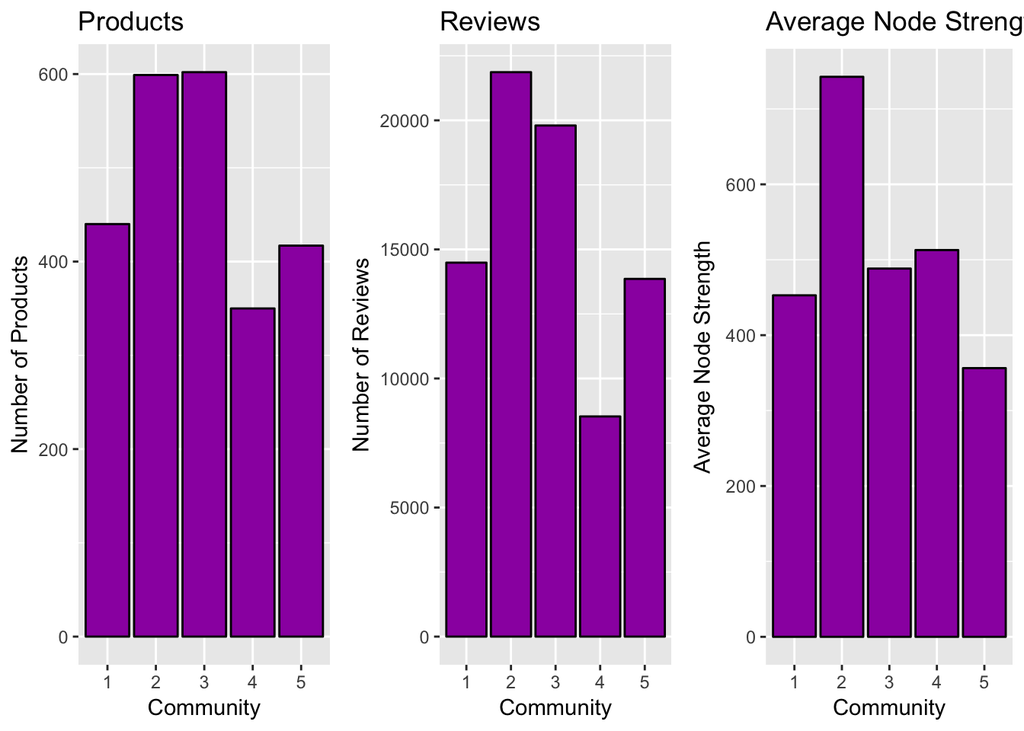

```r
g.5 <- delete_vertices(g.5, V(g.5)[V(g.5)$node_type == 'category'])
c.counts <- vapply(
  community_ids,
  function (i) length(V(g.5)[V(g.5)$community_id_le == i]),
  1
)
c.reviews <- vapply(
  community_ids,
  function (i) sum(V(g.5)[V(g.5)$community_id_le == i]$degree_in),
  1
)
g.5.strengths <- strength(g.5)
c.strengths <- vapply(
  community_ids,
  function (i) mean(g.5.strengths[V(g.5)$community_id_le == i]),
  1
)
helpful.frame.1 <- data.frame(
  Community=community_ids,
  Count=c.counts,
  Reviews=c.reviews,
  Strengths=c.strengths
)
f.prodPerComm <- ggplot(
  helpful.frame.1,
  aes(
    x=Community,
    y=Count
  )
) +
  geom_bar(
    stat="identity",
    color="black",
    fill=co.purple.0
  ) +
  ylab("Number of Products") +
  ggtitle("Products")
f.revPerComm <- ggplot(
  helpful.frame.1,
  aes(
    x=Community,
    y=Reviews
  )
) +
  geom_bar(
    stat="identity",
    color="black",
    fill=co.purple.0
  ) +
  ylab("Number of Reviews") +
  ggtitle("Reviews")
f.strengthPerComm <- ggplot(
  helpful.frame.1,
  aes(
    x=Community,
    y=Strengths
  )
) +
  geom_bar(
    stat="identity",
    color="black",
    fill=co.purple.0
  ) +
  ylab("Average Node Strength") +
  ggtitle("Average Node Strength")
multiplot(f.prodPerComm, f.revPerComm, f.strengthPerComm, cols=3)
```

#### Helpfulness and Genre

Visualize stats about helpfulness per genre. Interesting to note here that helpfulness vote totals are low in genre 2 even though it has the most products and reviews. To see if there’s any significance to the helpfulness statistics in determining genres, we run assortativity on it; unfortunately the value ends up very close to 0, meaing this attribute is not assortative negatively or positively. Maybe there is a different underlying attribute that accounts for the differences in genre 2?

```r
h.means.up <- vapply(
  community_ids,
  function (i) mean(V(g.5)[V(g.5)$community_id_le == i]$helpful_up_total),
  1
)
h.means.tot <- vapply(
  community_ids,
  function (i) mean(V(g.5)[V(g.5)$community_id_le == i]$helpful_total),
  1
)
helpful.frame.2 <- melt(data.frame(
  Community=community_ids,
  Yes=h.means.up,
  Total=h.means.tot
))
```

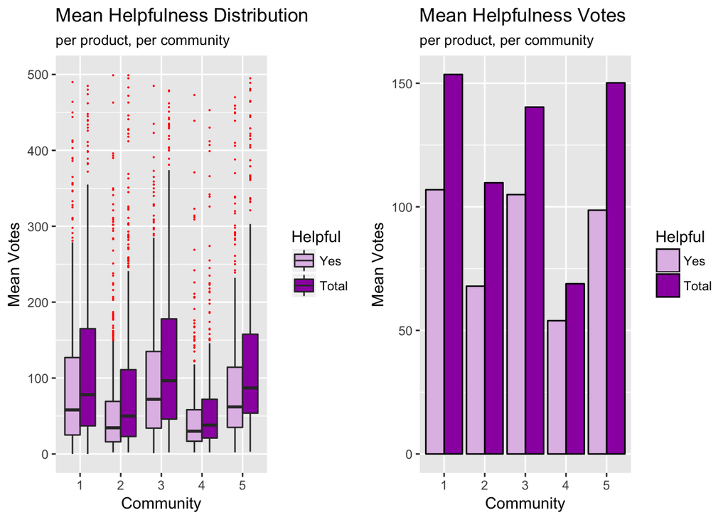

```r
f.helpBars <- ggplot(
  helpful.frame.2,
  aes(
    x=Community,
    y=value,
    group=variable,
    fill=variable
  )
) +
  geom_bar(
    stat="identity",
    color="black",
    position="dodge"
  ) +
  scale_fill_manual(values=c(co.purple.1, co.purple.0)) +
  ylab("Mean Votes") +
  ggtitle(
    "Mean Helpfulness Votes",
    subtitle="per product, per community"
  ) +
  guides(fill=guide_legend(title="Helpful"))
g.5.df.help <- data.frame(
  Community=V(g.5)$community_id_le,
  Yes=V(g.5)$helpful_up_total,
  Total=V(g.5)$helpful_total
)
g.5.df.help.melt <- melt(g.5.df.help, "Community")
f.helpPerComm <- ggplot(
  g.5.df.help.melt,
  aes(
    x=factor(Community),
    y=value,
    fill=factor(variable)
  )
) +
  geom_boxplot(
    outlier.size=0.05,
    outlier.color='red'
  ) +
  xlab("Community") +
  ylab("Mean Votes") +
  ylim(0, 500) +
  scale_fill_manual(values=c(co.purple.1, co.purple.0)) +
  guides(fill=guide_legend(title="Helpful")) +
  ggtitle(
    "Mean Helpfulness Distribution",
    subtitle="per product, per community"
  )
multiplot(f.helpPerComm, f.helpBars, cols=2)
```

```r
# is graph assortative on helpfulness
assortativity_nominal(g.5, types=cut(V(g.5)$helpful_total, 10), directed=FALSE)
```

```
## [1] 0.02023993
```

```r
assortativity_nominal(g.5, types=cut(V(g.5)$helpful_up_total, 10), directed=FALSE)
```

```
## [1] 0.027239
```

#### Rating and Genre

Visualize stats about rating per genre. Interesting to note here rating in genre 2 has a much wider distribution than in other genres. Also, genre 4 has a distribution highly skewed towards 5. Might be indicative of some underlying pattern in the genre. Unfortunately, here too, when running assortativity on the rating attribute we find that it’s value is very near 0, meaning this attribute has little correlation to these genres.

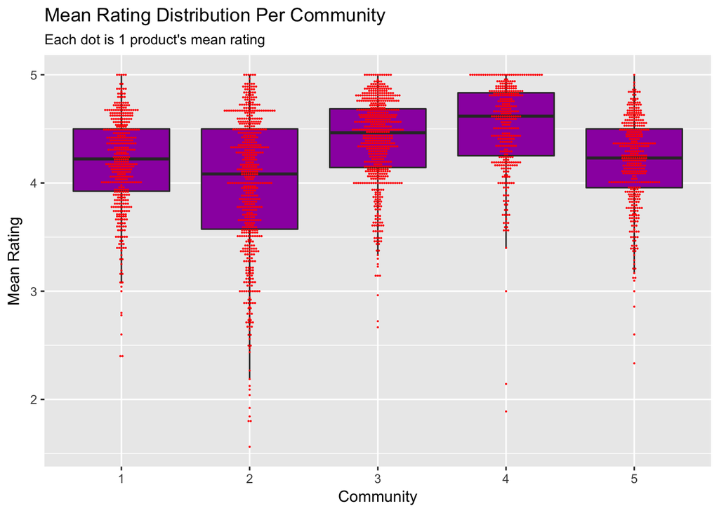

```r
g.5.df <- as.data.frame(
  list(
    RatingMean=V(g.5)$rating_mean,
    Community=V(g.5)$community_id_le
  ),
  stringsAsFactors=FALSE
)
ggplot(
  g.5.df,
  aes(
    factor(Community),
    RatingMean
  )
) +
  geom_boxplot(
    fill=co.purple.0,
    outlier.size=NA
  ) +
  geom_dotplot(
    binwidth=0.02,
    binaxis='y',
    stackdir='center',
    fill='red',
    color=NA
  ) +
  xlab("Community") +
  ylab("Mean Rating") +
  ggtitle(
    "Mean Rating Distribution Per Community",
    subtitle="Each dot is 1 product's mean rating"
  )
```

```r
# is graph assortative on review means
assortativity_nominal(g.5, types=cut(V(g.5)$rating_mean, 10), directed=FALSE)
```

```
## [1] 0.0455428
```

### CUG and QAP Testing for Kicks

The following section are CUG and QAP tests against the helpfulness and rating stats in our graph. Our graph is unique when compared against the randomly generated networks; unfortunately, given that the statistics are already very close to 0, these evaluations are not very meaningful.

```r
if(!require(sna)) install.packages('sna', repos='http://cran.us.r-project.org')
source('mycugtest.R')
source('myqaptest.R')
```

```r
g.5.cug.assort.help.tot <- mycugtest(
  g.5,
  assortativity_nominal,
  types=cut(V(g.5)$helpful_total, 10),
  directed=FALSE
)
g.5.qap.assort.help.tot <- myqaptest(
  g.5,
  assortativity_nominal,
  types=cut(V(g.5)$helpful_total, 10),
  directed=FALSE
)
g.5.cug.assort.help.up <- mycugtest(
  g.5,
  assortativity_nominal,
  types=cut(V(g.5)$helpful_up_total, 10),
  directed=FALSE
)
g.5.qap.assort.help.up <- myqaptest(
  g.5,
  assortativity_nominal,
  types=cut(V(g.5)$helpful_up_total, 10),
  directed=FALSE
)
saveRDS(g.5.cug.assort.help.tot, './_save/rand.help.cug.rds')
saveRDS(g.5.qap.assort.help.tot, './_save/rand.help.qap.rds')
saveRDS(g.5.cug.assort.help.up, './_save/rand.helpup.cug.rds')
saveRDS(g.5.qap.assort.help.up, './_save/rand.helpup.qap.rds')
```

```r
g.5.cug.assort.help.tot <- readRDS('./_save/rand.help.cug.rds')
g.5.qap.assort.help.tot <- readRDS('./_save/rand.help.qap.rds')
g.5.cug.assort.help.up <- readRDS('./_save/rand.helpup.cug.rds')
g.5.qap.assort.help.up <- readRDS('./_save/rand.helpup.qap.rds')
print.cug.test(g.5.cug.assort.help.tot)
```

```
##
## Univariate Conditional Uniform Graph Test
##
## Conditioning Method: size
## Graph Type:
## Diagonal Used: FALSE
## Replications: 1000
##
## Observed Value: 0.02023993
## Pr(X>=Obs): 0
## Pr(X<=Obs): 1
```

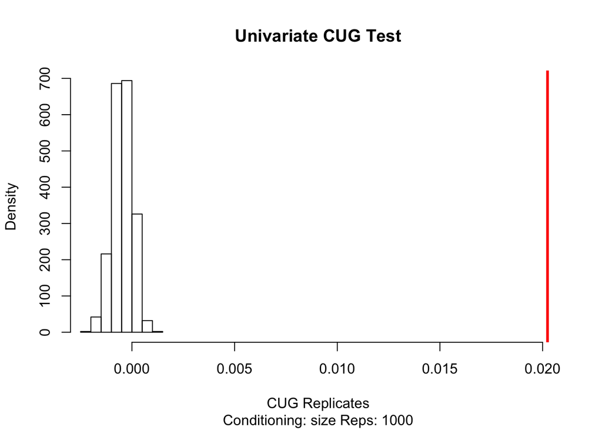

```r
plot.cug.test(g.5.cug.assort.help.tot)
```

```r
summary.qaptest(g.5.qap.assort.help.tot)
```

```
##
## QAP Test Results
##
## Estimated p-values:
##  p(f(perm) >= f(d)): 0
##  p(f(perm) <= f(d)): 1
##
## Test Diagnostics:
##  Test Value (f(d)): 0.02023993
##  Replications: 1000
##  Distribution Summary:
##      Min:     -0.005236707
##      1stQ:    -0.001806564
##      Med:     -0.0009356986
##      Mean:    -0.0008059264
##      3rdQ:    9.85181e-05
##      Max:     0.00626057
```

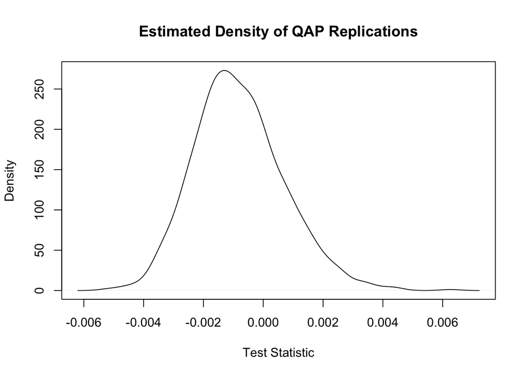

```r
plot.qaptest(g.5.qap.assort.help.tot)
```

```r
print.cug.test(g.5.cug.assort.help.up)
```

```
##
## Univariate Conditional Uniform Graph Test
##
## Conditioning Method: size
## Graph Type:
## Diagonal Used: FALSE
## Replications: 1000
##
## Observed Value: 0.027239
## Pr(X>=Obs): 0
## Pr(X<=Obs): 1
```

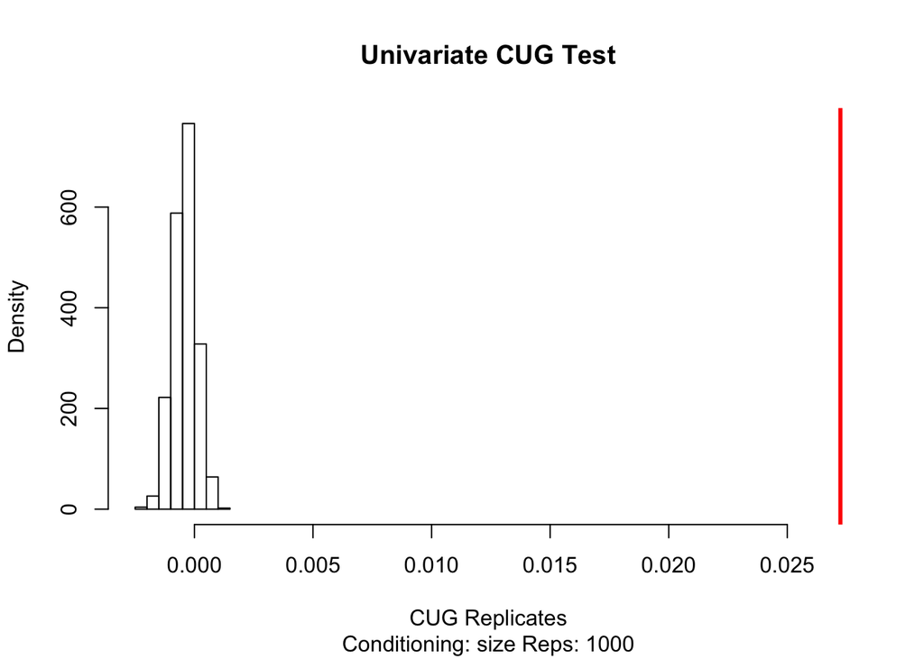

```r
plot.cug.test(g.5.cug.assort.help.up)
```

```r
summary.qaptest(g.5.qap.assort.help.up)
```

```
##
## QAP Test Results
##
## Estimated p-values:
##  p(f(perm) >= f(d)): 0
##  p(f(perm) <= f(d)): 1
##
## Test Diagnostics:
##  Test Value (f(d)): 0.027239
##  Replications: 1000
##  Distribution Summary:
##      Min:     -0.005105052
##      1stQ:    -0.001872755
##      Med:     -0.0008460018
##      Mean:    -0.0007757795
##      3rdQ:    0.000289795
##      Max:     0.004284887
```

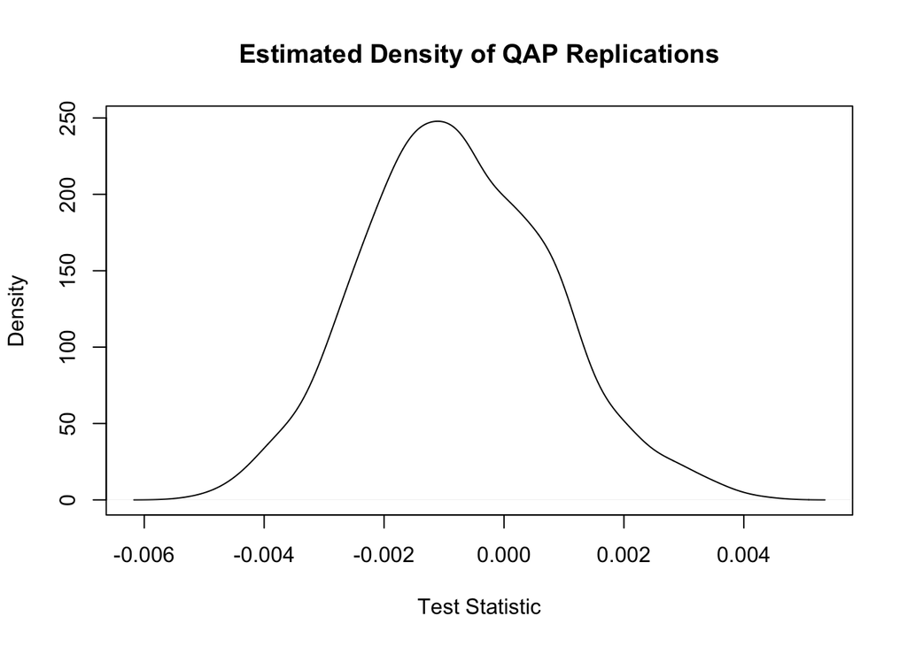

```r
plot.qaptest(g.5.qap.assort.help.up)
```

```r
g.5.cug.assort.rate <- mycugtest(
  g.5,
  assortativity_nominal,
  types=cut(V(g.5)$rating_mean, 10),
  directed=FALSE
)
g.5.qap.assort.rate <- myqaptest(
  g.5,
  assortativity_nominal,
  types=cut(V(g.5)$rating_mean, 10),
  directed=FALSE
)
saveRDS(g.5.cug.assort.rate, './_save/rand.rate.cug.rds')
saveRDS(g.5.qap.assort.rate, './_save/rand.rate.qap.rds')
```

```r
g.5.cug.assort.rate <- readRDS('./_save/rand.rate.cug.rds')
g.5.qap.assort.rate <- readRDS('./_save/rand.rate.qap.rds')
print.cug.test(g.5.cug.assort.rate)
```

```
##
## Univariate Conditional Uniform Graph Test
##
## Conditioning Method: size
## Graph Type:
## Diagonal Used: FALSE
## Replications: 1000
##
## Observed Value: 0.0455428
## Pr(X>=Obs): 0
## Pr(X<=Obs): 1
```

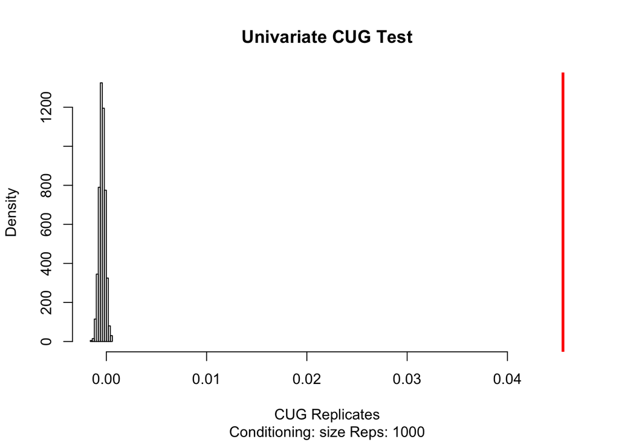

```r
plot.cug.test(g.5.cug.assort.rate)
```

```r
summary.qaptest(g.5.qap.assort.rate)
```

```
##
## QAP Test Results
##
## Estimated p-values:
##  p(f(perm) >= f(d)): 0
##  p(f(perm) <= f(d)): 1
##
## Test Diagnostics:
##  Test Value (f(d)): 0.0455428
##  Replications: 1000
##  Distribution Summary:
##      Min:     -0.00350873
##      1stQ:    -0.001436981
##      Med:     -0.0008103038
##      Mean:    -0.0007834875
##      3rdQ:    -0.0001520883
##      Max:     0.002459259
```

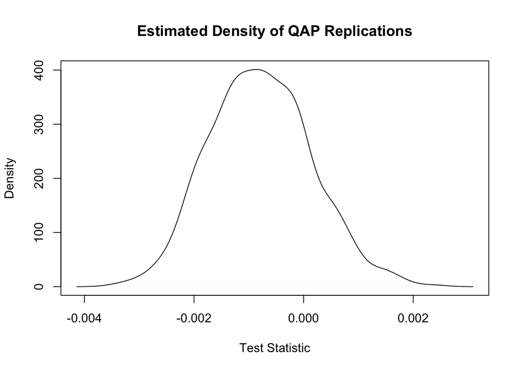

```r
plot.qaptest(g.5.qap.assort.rate)
```

### Betweenness

Product betweenness was calculated for these nodes using the `add_centrality_stats` function in `analysis.py`. Python is able to calculate this in a much more reasonable time than R; we’re unsure why in particular that is, but this graph is huge and small differences have a big effect.